# Global Political Violence Analysis: Protests and Riots (2020-2025)

**Kent Grass | Andrew ID: kgrass**  
**Date: December 5, 2025**

## Introduction

### Background and Motivation

The period from 2020 to 2025 has been marked by extraordinary global upheaval. The COVID-19 pandemic, economic disruptions, democratic backsliding in multiple regions, and ongoing geopolitical conflicts have created conditions ripe for civil unrest. From the Black Lives Matter protests in the United States to anti-government demonstrations in Hong Kong, from farmers' protests in India to political violence in Palestine, this era has witnessed an unprecedented wave of public demonstrations worldwide.

**Why this dataset?** I chose the Armed Conflict Location & Event Data Project (ACLED) dataset because it provides the most comprehensive, real-time tracking of political violence and protest events globally. As someone interested in public policy and international relations, understanding patterns of civil unrest is crucial for policymakers, NGOs, and researchers working to address the root causes of political instability. The recent escalation in Palestine following October 7, 2023, particularly drew my attention—I wanted to understand whether this represented a fundamentally new pattern or an acceleration of existing trends.

### Dataset Overview

This analysis examines political violence data from the **Armed Conflict Location & Event Data Project (ACLED)**, focusing specifically on protests and riots worldwide from 2020 to 2025.

**Dataset Characteristics:**

The ACLED dataset contains detailed records of each protest and riot event with the following key variables:

| Variable | Type | Description |
| --- | --- | --- |
| `event_date` | DateTime | Date of the event occurrence |
| `country` | Categorical | Country where event occurred |
| `location` | String | Specific city/region |
| `latitude` | Numeric | Geographic latitude coordinate |
| `longitude` | Numeric | Geographic longitude coordinate |
| `event_type` | Categorical | Classification: "Protests" vs "Riots" |
| `fatalities` | Numeric | Number of deaths associated with event |
| `tags` | String | Metadata including crowd size estimates |

The population dataset provides country-level demographic information used for per capita normalization:

| Variable | Type | Description |
| --- | --- | --- |
| `country` | String | Country name |
| `population` | Numeric | Total population count (2024 estimates) |

### Initial Hypotheses

Before conducting this analysis, I developed several hypotheses based on common narratives in media and policy discussions:

1. **Weather/Seasonal Hypothesis**: Political demonstrations might follow seasonal patterns, with more activity during mild weather months when outdoor gatherings are more comfortable. This could explain the cyclical patterns observed in global trends.
2. **Palestine Escalation Hypothesis**: The events of October 7, 2023, marked a dramatic shift in violence levels in Palestine, representing a break from previous patterns rather than a continuation of existing trends.
3. **Population Size Correlation**: Countries with larger populations would naturally have more protests in absolute numbers, but per capita rates might reveal different patterns related to political culture and democratic norms.
4. **Geographic Concentration**: Protests and riots would cluster in specific "hotspot" regions characterized by political instability, with limited geographic spread.

### Research Questions

To test these hypotheses and explore the data, I formulated four primary research questions:

1. **Geographic Distribution**: Which countries experience the highest rates of protests and riots when adjusted for population? Does this reveal patterns beyond simple population size?
2. **Temporal Trends**: Has violence escalated in Palestine following October 7, 2023, or was this spike part of a longer-term upward trend?
3. **Seasonal Patterns**: Do protests follow seasonal patterns globally? If so, can these be attributed to weather conditions?
4. **Weather Hypothesis**: Does climate/weather influence protest activity when controlling for hemisphere differences (where seasons are opposite)?

### Analytical Approach

To answer these questions, I will:

- Conduct geographic analysis using both absolute counts and per capita rates
- Perform temporal trend analysis with linear regression to identify patterns
- Test seasonal hypotheses by controlling for hemisphere
- Create interactive visualizations to reveal spatial and temporal patterns
- Draw evidence-based conclusions about the drivers of political violence

## 1. Data Loading, Preparation and Exploration

```python
import pandas as pd
import numpy as np
import matplotlib.pyplot as plt
import plotly.express as px
import re
import warnings
warnings.filterwarnings('ignore', category=DeprecationWarning)
```

```python
df = pd.read_csv('ACLED Data_2025-12-03.csv')
```

```python
population_df = pd.read_csv('Population - total.csv', thousands=',')
population_df = population_df.rename(columns={'value': 'population'})
```

```python
# Display ACLED dataset overview
print("ACLED Dataset Overview:")
print(f"Shape: {df.shape[0]:,} rows × {df.shape[1]} columns")
print("\nColumn Information:")
df.info()
print("\nSample of data:")
df.head()
```

```
ACLED Dataset Overview:
Shape: 994,049 rows × 31 columns

Column Information:
<class 'pandas.core.frame.DataFrame'>
RangeIndex: 994049 entries, 0 to 994048
Data columns (total 31 columns):
 #   Column              Non-Null Count   Dtype
---  ------              --------------   -----
 0   event_id_cnty       994049 non-null  object
 1   event_date          994049 non-null  object
 2   year                994049 non-null  int64
 3   time_precision      994049 non-null  int64
 4   disorder_type       994049 non-null  object
 5   event_type          994049 non-null  object
```

[output cut: 29 more lines]

|  | event_id_cnty | event_date | year | time_precision | disorder_type | event_type | sub_event_type | actor1 | assoc_actor_1 | inter1 | ... | location | latitude | longitude | geo_precision | source | source_scale | notes | fatalities | tags | timestamp |
| --- | --- | --- | --- | --- | --- | --- | --- | --- | --- | --- | --- | --- | --- | --- | --- | --- | --- | --- | --- | --- | --- |
| 0 | IRN5946 | 2020-01-01 | 2020 | 1 | Demonstrations | Protests | Peaceful protest | Protesters (Iran) | Students (Iran) | Protesters | ... | Shiraz | 29.6103 | 52.5311 | 1 | Eteraze Bazar | New media | On 1 January 2020, a group of students at the ... | 0 | crowd size=no report | 1578503875 |
| 1 | IRN5874 | 2020-01-01 | 2020 | 1 | Demonstrations | Protests | Peaceful protest | Protesters (Iran) | Health Workers (Iran) | Protesters | ... | Mashhad | 36.3156 | 59.5680 | 1 | Iranian Labour News Agency | National | On 1 January 2020, a group of nurses held a pr... | 0 | crowd size=no report | 1578503875 |
| 2 | TUN6016 | 2020-01-01 | 2020 | 1 | Demonstrations | Protests | Peaceful protest | Protesters (Tunisia) | UGTT: Tunisian General Labour Union; Labor Gro... | Protesters | ... | Tataouine | 32.9297 | 10.4518 | 2 | Al Chourouk | National | On 1 January 2020, near Tataouine, workers at ... | 0 | crowd size=no report | 1578512391 |
| 3 | ALG7956 | 2020-01-01 | 2020 | 1 | Demonstrations | Protests | Peaceful protest | Protesters (Algeria) | NaN | Protesters | ... | Seddouk | 36.5472 | 4.6861 | 1 | Liberte (Algeria) | National | On 1 January 2020, residents of Seddouk protes... | 0 | crowd size=hundreds | 1579554012 |
| 4 | ARG1267 | 2020-01-01 | 2020 | 1 | Demonstrations | Riots | Violent demonstration | Rioters (Argentina) | Prisoners (Argentina) | Rioters | ... | Santiago del Estero | -27.7984 | -64.2728 | 1 | El Liberal | Subnational | On 1 January 2020, in Santiago del Estero (San... | 0 | crowd size=no report | 1618524821 |

5 rows × 31 columns

```python
# Display population dataset overview
print("Population Dataset Overview:")
print(f"Shape: {population_df.shape[0]:,} rows × {population_df.shape[1]} columns")
print(f"\nPopulation statistics:")
print(f"  Minimum: {population_df['population'].min():,.0f}")
print(f"  Maximum: {population_df['population'].max():,.0f}")
print(f"  Median: {population_df['population'].median():,.0f}")
print(f"  Mean: {population_df['population'].mean():,.0f}")
print("\nColumn Information:")
population_df.info()
print("\nSample of data:")
population_df.head()
```

```
Population Dataset Overview:
Shape: 237 rows × 6 columns

Population statistics:
  Minimum: 50
  Maximum: 1,416,043,270
  Median: 5,563,649
  Mean: 33,996,850

Column Information:
<class 'pandas.core.frame.DataFrame'>
RangeIndex: 237 entries, 0 to 236
Data columns (total 6 columns):
 #   Column               Non-Null Count  Dtype
---  ------               --------------  -----
 0   name                 237 non-null    object
 1   slug                 237 non-null    object
 2   population           237 non-null    int64
 3   date_of_information  237 non-null    int64
 4   ranking              237 non-null    int64
 5   region               237 non-null    object
dtypes: int64(3), object(3)
memory usage: 11.2+ KB

Sample of data:
```

|  | name | slug | population | date_of_information | ranking | region |
| --- | --- | --- | --- | --- | --- | --- |
| 0 | China | china | 1416043270 | 2024 | 1 | East and Southeast Asia |
| 1 | India | india | 1409128296 | 2024 | 2 | South Asia |
| 2 | United States | united-states | 341963408 | 2024 | 3 | North America |
| 3 | Indonesia | indonesia | 281562465 | 2024 | 4 | East and Southeast Asia |
| 4 | Pakistan | pakistan | 252363571 | 2024 | 5 | South Asia |

## 2. Geographic Analysis: Where Are Protests Happening?

First, let's identify which countries have experienced the most protests and riots during this period.

```python
# Aggregate ACLED data by country
country_events = df.groupby('country').size().reset_index(name='total_events')

# Separate counts for protests and riots
protests_by_country = df[df['event_type'] == 'Protests'].groupby('country').size().reset_index(name='protests')
riots_by_country = df[df['event_type'] == 'Riots'].groupby('country').size().reset_index(name='riots')

# Merge all event counts into country_events
country_events = country_events.merge(protests_by_country, on='country', how='left')
country_events = country_events.merge(riots_by_country, on='country', how='left')
#country_events = country_events.fillna(0)
```

```python
# Convert event_date to datetime
df['event_date'] = pd.to_datetime(df['event_date'])

# Create a year-month column for grouping
df['year_month'] = df['event_date'].dt.to_period('M')
```

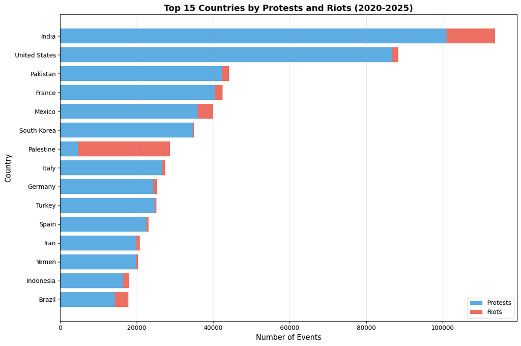

```python
# Get top 15 countries by total events
top_countries = country_events.nlargest(15, 'total_events').sort_values('total_events')

# Create horizontal stacked bar chart
fig, ax = plt.subplots(figsize=(12, 8))

# Plot protests (blue) and riots (red) as stacked bars
ax.barh(top_countries['country'], top_countries['protests'],
        label='Protests', color='#3498db', alpha=0.8)
ax.barh(top_countries['country'], top_countries['riots'],
        left=top_countries['protests'],
        label='Riots', color='#e74c3c', alpha=0.8)

ax.set_xlabel('Number of Events', fontsize=12)
ax.set_ylabel('Country', fontsize=12)
ax.set_title('Top 15 Countries by Protests and Riots (2020-2025)',
             fontsize=14, fontweight='bold')
ax.legend(loc='lower right', fontsize=10)
ax.grid(True, alpha=0.3, axis='x')

plt.tight_layout()
plt.show()
```

Here we can see that the top 3 countries with the most protests and riots are the United States, India, and Pakistan. Palestine is the only country with more riots than protests. Is this because of recent excalations in the region? Let's visualize this data to get a better understanding.

## 3. Case Study: Palestine and the October 7, 2023 Escalation

Palestine stands out as the only country in the top 15 with more riots than protests. Let's investigate whether this pattern changed after October 7, 2023.

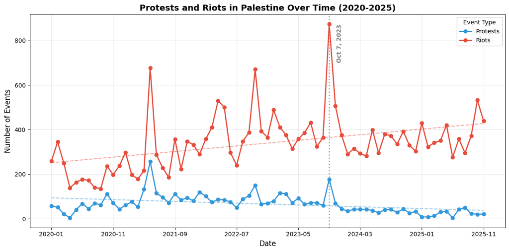

```python
# Filter data for Palestine
palestine_df = df[df['country'] == 'Palestine']

# Group by year-month and event type, count events
palestine_events = palestine_df.groupby(['year_month', 'event_type']).size().reset_index(name='count')

# Convert period to string for plotting
palestine_events['year_month'] = palestine_events['year_month'].astype(str)

# Create the line plot
fig, ax = plt.subplots(figsize=(12, 6))

# Plot each event type with LINEAR trend lines
for event_type, color in [('Protests', '#3498db'), ('Riots', '#e74c3c')]:
    data = palestine_events[palestine_events['event_type'] == event_type]

    # Plot actual data
    ax.plot(data['year_month'], data['count'], marker='o', label=event_type,
            linewidth=2, color=color)

    # Add LINEAR trend line (degree 1)
    x_numeric = np.arange(len(data))
    z = np.polyfit(x_numeric, data['count'], 1)
    p = np.poly1d(z)
    ax.plot(data['year_month'], p(x_numeric), '--', linewidth=1.5,
            color=color, alpha=0.5)

# Add vertical line for October 7, 2023
oct_7_marker = '2023-10'
all_months = sorted(palestine_events['year_month'].unique())
if oct_7_marker in all_months:
    oct_7_position = all_months.index(oct_7_marker)
    ax.axvline(x=oct_7_position, color='grey', linestyle=':', linewidth=2, alpha=0.7)
    ax.text(oct_7_position + 1.2, ax.get_ylim()[1] * 0.95, 'Oct 7, 2023',
            rotation=90, verticalalignment='top', color='grey', fontsize=10, fontweight='bold')

ax.set_xlabel('Date', fontsize=12)
ax.set_ylabel('Number of Events', fontsize=12)
ax.set_title('Protests and Riots in Palestine Over Time (2020-2025)', fontsize=14, fontweight='bold')
ax.legend(title='Event Type', fontsize=10)

# Show only every 8th date label to avoid crowding
xticks = ax.get_xticks()
ax.set_xticks(xticks[::10])

ax.grid(True, alpha=0.3)
plt.tight_layout()
plt.show()
```

Here we can see there has been an increase in riots in Palestine since 2020. We can see a spike for October 7th. This suggests that the number of riots was trending upwards before the recent escalations.

## 4. Global Temporal Trends

Now let's examine how protest and riot activity has evolved globally over the 2020-2025 period.

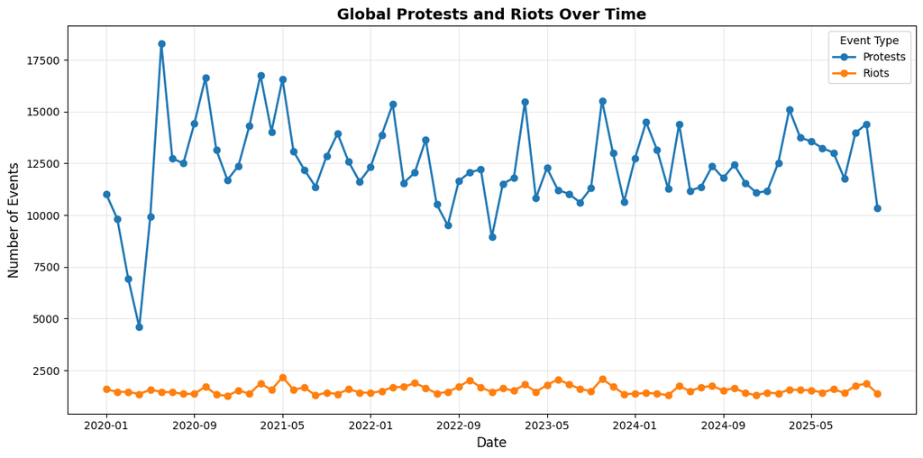

```python
# Group by year-month and event type, count events
events_over_time = df.groupby(['year_month', 'event_type']).size().reset_index(name='count')

# Convert period to string for plotting
events_over_time['year_month'] = events_over_time['year_month'].astype(str)

# Create the line plot
plt.figure(figsize=(12, 6))

# Plot each event type
for event_type in ['Protests', 'Riots']:
    data = events_over_time[events_over_time['event_type'] == event_type]
    plt.plot(data['year_month'], data['count'], marker='o', label=event_type, linewidth=2)

plt.xlabel('Date', fontsize=12)
plt.ylabel('Number of Events', fontsize=12)
plt.title('Global Protests and Riots Over Time', fontsize=14, fontweight='bold')
plt.legend(title='Event Type', fontsize=10)

# Show only every 4th date label (25% of dates)
xticks = plt.gca().get_xticks()
plt.gca().set_xticks(xticks[::8])
#plt.xticks(rotation=45, ha='right')

plt.grid(True, alpha=0.3)
plt.tight_layout()
plt.show()
```

It seems there is some type of cyclical pattern in the data, with peaks occurring at regular intervals. This could indicate that certain times of the year are more prone to protests and riots, possibly due to political events, anniversaries, or seasonal factors. Further analysis could help identify the specific causes behind these patterns.

## 5. Seasonal Analysis: Testing the Weather Hypothesis

The global trend chart suggests cyclical patterns. Could weather or seasons influence when people protest?

```python
# Extract month from event_date to analyze seasonal patterns
df['month'] = df['event_date'].dt.month
df['month_name'] = df['event_date'].dt.strftime('%B')

# Group by month and event type
monthly_patterns = df.groupby(['month', 'month_name', 'event_type']).size().reset_index(name='count')

# Focus on Protests to see monthly peaks
protests_by_month = monthly_patterns[monthly_patterns['event_type'] == 'Protests'].sort_values('month')
```

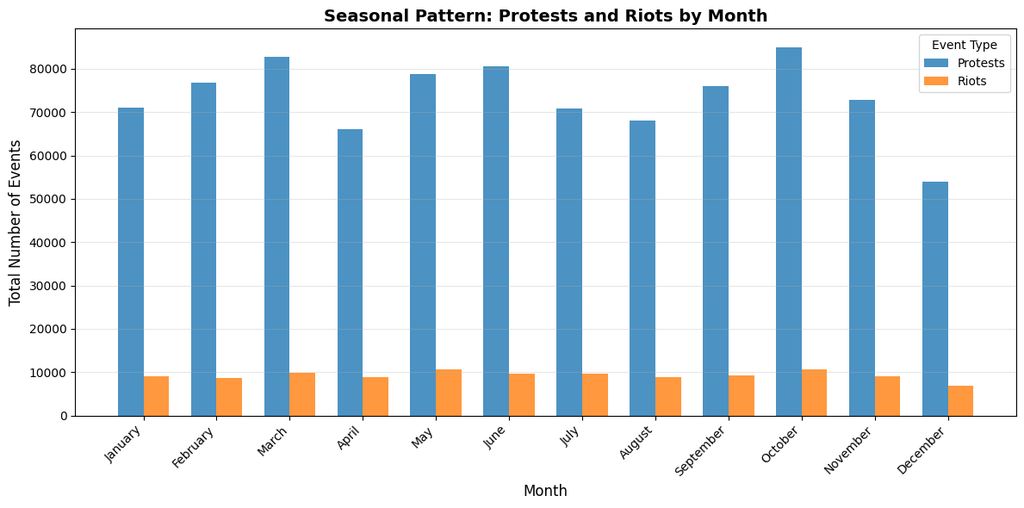

```python
# Visualize the seasonal pattern with a bar graph
plt.figure(figsize=(12, 6))

# Prepare data for grouped bar chart
protests_data = monthly_patterns[monthly_patterns['event_type'] == 'Protests'].sort_values('month')
riots_data = monthly_patterns[monthly_patterns['event_type'] == 'Riots'].sort_values('month')

x = np.arange(len(protests_data))  # Position for each month
width = 0.35  # Width of bars

plt.bar(x - width/2, protests_data['count'], width, label='Protests', alpha=0.8)
plt.bar(x + width/2, riots_data['count'], width, label='Riots', alpha=0.8)

plt.xlabel('Month', fontsize=12)
plt.ylabel('Total Number of Events', fontsize=12)
plt.title('Seasonal Pattern: Protests and Riots by Month', fontsize=14, fontweight='bold')
plt.xticks(x, protests_data['month_name'], rotation=45, ha='right')
plt.legend(title='Event Type', fontsize=10)
plt.grid(True, alpha=0.3, axis='y')
plt.tight_layout()
plt.show()
```

From this graph I do not see any seasonal cycle variance. This could because the data is global and this seasons are inverse for the global north and south. Let's investigate.

### Hemisphere Distribution

Let's examine how events are distributed across hemispheres to control for seasonal differences.

```python
# Use latitude to determine hemisphere
# Positive latitude = Northern Hemisphere, Negative = Southern Hemisphere
df['hemisphere'] = df['latitude'].apply(lambda x: 'Northern' if x >= 0 else 'Southern')

# Check the distribution
print("Events by Hemisphere:")
print(df['hemisphere'].value_counts())
print(f"\nPercentage in Northern Hemisphere: {(df['hemisphere'] == 'Northern').sum() / len(df) * 100:.1f}%")
```

```
Events by Hemisphere:
hemisphere
Northern    875004
Southern    119045
Name: count, dtype: int64

Percentage in Northern Hemisphere: 88.0%
```

```python
# Analyze protests by month for each hemisphere
protests_only = df[df['event_type'] == 'Protests']

hemisphere_monthly = protests_only.groupby(['hemisphere', 'month', 'month_name']).size().reset_index(name='count')

# Get data for each hemisphere
northern = hemisphere_monthly[hemisphere_monthly['hemisphere'] == 'Northern'].sort_values('month')
southern = hemisphere_monthly[hemisphere_monthly['hemisphere'] == 'Southern'].sort_values('month')
```

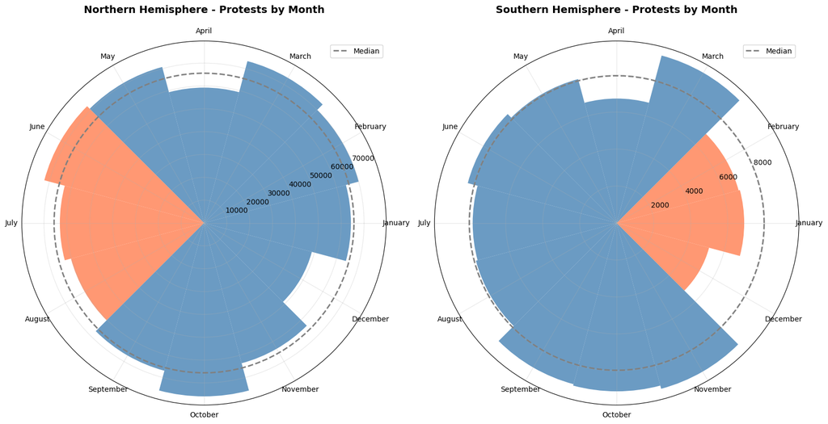

```python
# Create polar plot for protests by month and hemisphere
fig, (ax1, ax2) = plt.subplots(1, 2, figsize=(16, 8), subplot_kw=dict(projection='polar'))

# Prepare angle positions for 12 months
theta = np.linspace(0, 2 * np.pi, 12, endpoint=False)
width = 2 * np.pi / 12

# Calculate medians
northern_median = northern['count'].median()
southern_median = southern['count'].median()

# Northern Hemisphere
bars_north = ax1.bar(theta, northern['count'], width=width,
                      color=['coral' if m in ['June', 'July', 'August'] else 'steelblue'
                             for m in northern['month_name']], alpha=0.8)
# Add median circle
theta_circle = np.linspace(0, 2 * np.pi, 100)
ax1.plot(theta_circle, [northern_median] * 100, 'gray', linestyle='--', linewidth=2, label='Median')
ax1.set_xticks(theta)
ax1.set_xticklabels(northern['month_name'])
ax1.set_title('Northern Hemisphere - Protests by Month', fontsize=14, fontweight='bold', pad=20)
ax1.legend(loc='upper right', fontsize=10)
ax1.grid(True, alpha=0.3)

# Southern Hemisphere
bars_south = ax2.bar(theta, southern['count'], width=width,
                      color=['coral' if m in ['December', 'January', 'February'] else 'steelblue'
                             for m in southern['month_name']], alpha=0.8)
# Add median circle
ax2.plot(theta_circle, [southern_median] * 100, 'gray', linestyle='--', linewidth=2, label='Median')
ax2.set_xticks(theta)
ax2.set_xticklabels(southern['month_name'])
ax2.set_title('Southern Hemisphere - Protests by Month', fontsize=14, fontweight='bold', pad=20)
ax2.legend(loc='upper right', fontsize=10)
ax2.grid(True, alpha=0.3)

plt.tight_layout()
plt.show()
```

Here we can see that there is not a clear seasonal pattern for protests when split by hemisphere. This suggests that weather or seasons may not be a significant factor influencing the occurrence of protests globally. Other factors, such as political events, social issues, or economic conditions, might play a more substantial role in driving protest activity throughout the year. Further analysis could explore these other potential influences to better understand the drivers behind protest occurrences.

## 6. Choropleth Maps: Events per Capita by Country

```python
# Merge the datasets
map_data = country_events.merge(population_df, left_on='country', right_on=population_df.columns[0], how='inner')

# Calculate events per capita (per 100,000 people)
map_data['events_per_100k'] = (map_data['total_events'] / map_data['population']) * 100000
map_data['protests_per_100k'] = (map_data['protests'] / map_data['population']) * 100000
map_data['riots_per_100k'] = (map_data['riots'] / map_data['population']) * 100000
```

```python
# Create two choropleth maps - one for protests, one for riots
# Clean the data - remove any rows with infinite or NaN values
# Also filter out countries with very small populations (< 1 million) to avoid skewed per capita rates
min_population = 1_000_000
map_data_clean = map_data[
    map_data['protests_per_100k'].notna() & np.isfinite(map_data['protests_per_100k']) &
    map_data['riots_per_100k'].notna() & np.isfinite(map_data['riots_per_100k']) &
    (map_data['population'] >= min_population)
].copy()

# Map 1: Protests per Capita
fig_protests = px.choropleth(map_data_clean,
                    locations='country',
                    locationmode='country names',
                    color='protests_per_100k',
                    hover_name='country',
                    hover_data={
                        'country': False,
                        'protests_per_100k': ':.2f',
                        'protests': ':,',
                        'population': ':,.0f'
                    },
                    color_continuous_scale='Blues',
                    title='Protests per 100,000 People by Country (2020-2025)',
                    labels={'protests_per_100k': 'Protests per 100k'},
                    range_color=[0, map_data_clean['protests_per_100k'].quantile(0.95)]
                    )

fig_protests.update_layout(
    geo=dict(
        showframe=False,
        showcoastlines=True,
        projection_type='natural earth'
    ),
    height=600,
    title_font_size=16
)

fig_protests.show()

# Map 2: Riots per Capita
fig_riots = px.choropleth(map_data_clean,
                    locations='country',
                    locationmode='country names',
                    color='riots_per_100k',
                    hover_name='country',
                    hover_data={
                        'country': False,
                        'riots_per_100k': ':.2f',
                        'riots': ':,',
                        'population': ':,.0f'
                    },
                    color_continuous_scale='Reds',
                    title='Riots per 100,000 People by Country (2020-2025)',
                    labels={'riots_per_100k': 'Riots per 100k'},
                    range_color=[0, map_data_clean['riots_per_100k'].quantile(0.95)]
                    )

fig_riots.update_layout(
    geo=dict(
        showframe=False,
        showcoastlines=True,
        projection_type='natural earth'
    ),
    height=600,
    title_font_size=16
)

fig_riots.show()
```

[output not shown]

Here we filtered out countries with small populations (<1 million) to avoid skewed per capita rates.

The protest map reveals some striking patterns. **Europe shows particularly high rates of protests per capita**, with countries like Sweden, Serbia, and several Southern European nations (such as Greece, Spain, and France) displaying some of the highest protest activity globally. This suggests that protest is a common form of political expression in these democracies. South America also shows elevated protest rates, particularly in countries like Chile and Colombia, while certain African nations appear with moderate to high rates.

The riots map tells a different story. While some overlap exists with the protest map, **riots appear more concentrated in specific regions** including parts of Africa and South America. Notably, some European countries with high protest rates show relatively lower riot rates, suggesting that while protest activity is common, it less frequently escalates to riots in these regions.

These geographic patterns suggest that political violence is not evenly distributed globally and may be influenced by regional factors such as democratic norms, political stability, economic conditions, and cultural attitudes toward public demonstration. The distinction between protest-heavy and riot-heavy countries may reflect differences in how civil society engages with government and how authorities respond to dissent.

## 7. Animated Global Visualization

To visualize the temporal and spatial evolution of protests and riots, we'll create an animated map showing events over time with crowd sizes and cumulative fatalities.

```python
def parse_crowd_size(tag):
    """
    Parse crowd size from tags and return a category and estimated number.
    Categories: Small (1-99), Medium (100-999), Large (1000-9999), Very Large (10000+)
    """
    if pd.isna(tag) or 'no report' in tag.lower():
        return 'Unknown', 0

    # Extract the crowd size portion
    match = re.search(r'crowd size=(.+)', tag, re.IGNORECASE)
    if not match:
        return 'Unknown', 0

    crowd_str = match.group(1).lower()

    # Handle text descriptions
    if 'million' in crowd_str or 'millions' in crowd_str:
        return 'Very Large', 100000
    elif 'hundred thousand' in crowd_str or 'hundreds of thousands' in crowd_str:
        return 'Very Large', 50000
    elif 'ten thousand' in crowd_str or 'tens of thousands' in crowd_str:
        return 'Very Large', 15000
    elif 'thousand' in crowd_str or 'thousands' in crowd_str:
        return 'Large', 2000
    elif 'hundred' in crowd_str or 'hundreds' in crowd_str:
        return 'Medium', 500
    elif 'dozen' in crowd_str or 'dozens' in crowd_str:
        return 'Small', 30
    elif 'few' in crowd_str:
        return 'Small', 10

    # Extract numbers
    numbers = re.findall(r'[\d,]+', crowd_str.replace(',', ''))
    if numbers:
        try:
            # Take the maximum if there's a range
            num = max([int(n.replace(',', '')) for n in numbers])

            if num >= 10000:
                return 'Very Large', num
            elif num >= 1000:
                return 'Large', num
            elif num >= 100:
                return 'Medium', num
            else:
                return 'Small', num
        except:
            pass

    return 'Unknown', 0

# Apply the parsing function
df['crowd_category'], df['crowd_estimate'] = zip(*df['tags'].apply(parse_crowd_size))
```

```python
# Prepare data for animated visualization
# Create a date column for daily aggregation
df['date'] = df['event_date'].dt.date
df['date_str'] = df['event_date'].dt.strftime('%Y-%m-%d')

# Calculate cumulative fatalities by date
fatalities_cumsum = df.groupby('date_str')['fatalities'].sum().cumsum().reset_index()
fatalities_cumsum.columns = ['date_str', 'cumulative_fatalities']

# For the animation, we need each event as a point
# Filter to events with known locations and add cumulative fatalities
anim_df = df[df['latitude'].notna() & df['longitude'].notna()].copy()
anim_df = anim_df.merge(fatalities_cumsum, on='date_str', how='left')
anim_df['cumulative_fatalities'] = anim_df['cumulative_fatalities'].fillna(0)

# Map crowd size categories to marker sizes
size_map = {
    'Unknown': 3,
    'Small': 5,
    'Medium': 10,
    'Large': 20,
    'Very Large': 35
}
anim_df['marker_size'] = anim_df['crowd_category'].map(size_map)

# Sort by date
anim_df = anim_df.sort_values('date_str')
```

```python
# Color mapping for event types
color_map = {
    'Protests': '#3498db',  # Blue
    'Riots': '#e74c3c'      # Red
}

fig = px.scatter_geo(anim_df,
                     lat='latitude',
                     lon='longitude',
                     color='event_type',
                     size='marker_size',
                     animation_frame='date_str',
                     hover_name='location',
                     hover_data={
                         'event_type': True,
                         'crowd_category': True,
                         'crowd_estimate': ':,',
                         'fatalities': True,
                         'cumulative_fatalities': ':,',
                         'country': True,
                         'date_str': False,
                         'latitude': False,
                         'longitude': False,
                         'marker_size': False
                     },
                     color_discrete_map=color_map,
                     size_max=20,
                     projection='natural earth',
                     title='Global Protests and Riots: 2020-2025<br><sub>Circle size indicates crowd size | Colors: Blue=Protests, Red=Riots</sub>'
                    )

# Update layout for better visualization
fig.update_layout(
    height=700,
    title_font_size=18,
    geo=dict(
        showland=True,
        landcolor='rgb(243, 243, 243)',
        coastlinecolor='rgb(204, 204, 204)',
        showlakes=True,
        lakecolor='rgb(255, 255, 255)',
        showcountries=True,
        countrycolor='rgb(204, 204, 204)',
        projection_type='natural earth'
    ),
    updatemenus=[{
        'buttons': [
            {
                'args': [None, {'frame': {'duration': 50, 'redraw': True},
                               'fromcurrent': True, 'transition': {'duration': 0}}],
                'label': 'Play',
                'method': 'animate'
            },
            {
                'args': [[None], {'frame': {'duration': 0, 'redraw': True},
                                 'mode': 'immediate',
                                 'transition': {'duration': 0}}],
                'label': 'Pause',
                'method': 'animate'
            }
        ],
        'direction': 'left',
        'pad': {'r': 10, 't': 87},
        'showactive': False,
        'type': 'buttons',
        'x': 0.1,
        'xanchor': 'right',
        'y': 0,
        'yanchor': 'top'
    }]
)

# Add cumulative fatality counter as annotation
for frame in fig.frames:
    date = frame.name
    if date in fatalities_cumsum['date_str'].values:
        cum_fat = int(fatalities_cumsum[fatalities_cumsum['date_str'] == date]['cumulative_fatalities'].iloc[0])
    else:
        cum_fat = 0

    frame.layout.update(
        annotations=[
            dict(
                text=f'<b>Cumulative Fatalities: {cum_fat:,}</b>',
                x=0.02,
                y=0.98,
                xref='paper',
                yref='paper',
                showarrow=False,
                font=dict(size=16, color='darkred'),
                bgcolor='rgba(255, 255, 255, 0.8)',
                bordercolor='darkred',
                borderwidth=2,
                borderpad=10
            )
        ]
    )

# Add initial annotation
cum_fat_initial = int(anim_df.iloc[0]['cumulative_fatalities'])
fig.add_annotation(
    text=f'<b>Cumulative Fatalities: {cum_fat_initial:,}</b>',
    x=0.02,
    y=0.98,
    xref='paper',
    yref='paper',
    showarrow=False,
    font=dict(size=16, color='darkred'),
    bgcolor='rgba(255, 255, 255, 0.8)',
    bordercolor='darkred',
    borderwidth=2,
    borderpad=10
)

fig = px.scatter_geo(anim_df,
                     lat='latitude',
                     lon='longitude',
                     color='event_type',
                     size='marker_size',
                     animation_frame='date_str',
                     hover_name='location',
                     hover_data={
                         'event_type': True,
                         'crowd_category': True,
                         'crowd_estimate': ':,',
                         'fatalities': True,
                         'cumulative_fatalities': ':,',
                         'country': True,
                         'date_str': False,
                         'latitude': False,
                         'longitude': False,
                         'marker_size': False
                     },
                     color_discrete_map=color_map,
                     size_max=20,
                     projection='natural earth',
                     title='Global Protests and Riots: 2020-2025<br><sub>Circle size indicates crowd size</sub>',
                     labels={
                         'event_type': 'Event Type',
                         'crowd_category': 'Crowd Category',
                         'crowd_estimate': 'Crowd Estimate',
                         'fatalities': 'Fatalities',
                         'cumulative_fatalities': 'Cumulative Fatalities',
                         'country': 'Country',
                         'location': 'Location',
                         'date_str': 'Date'
                     }
                    )

fig.show()
```

[output not shown]

## Conclusions and Key Findings

### 1. Geographic Patterns

Our per capita analysis reveals that **protest activity is not simply a function of population size**. European nations, particularly in Southern and Eastern Europe, show remarkably high protest rates per capita, suggesting that democratic systems and political culture play significant roles. The United States, India, and Pakistan lead in absolute numbers, but countries like Serbia and Chile lead in per capita rates.

### 2. Palestine: Pre-existing Upward Trend

The data shows that **riots in Palestine were already trending upward before October 7, 2023**. While there was a spike following that date, the linear trend line suggests this was an acceleration of existing patterns rather than an entirely new phenomenon. This finding challenges narratives that attribute all recent violence solely to post-October 7 events.

### 4. Protests vs. Riots: Different Geographic Signatures

The choropleth maps reveal that **protests and riots have distinct geographic patterns**. While Europe shows high protest rates, these rarely escalate to riots. Conversely, some regions show lower protest rates but higher riot rates, potentially indicating differences in:

- Democratic institutions and norms
- Police response tactics
- Economic inequality
- Political stability

### Limitations and Future Research

- **Reporting Bias:** ACLED data may be more complete for some regions than others
- **Definition Challenges:** The line between "protest" and "riot" can be subjective
- **Missing Variables:** Economic indicators, government response data, and media coverage could enhance this analysis
- **Causation:** This analysis identifies correlations but cannot establish causal relationships

### Final Thoughts

This analysis demonstrates that political violence is a complex phenomenon driven primarily by political, social, and economic factors rather than simple environmental ones. The patterns we observe reflect deep structural differences in how societies organize, how governments respond to dissent, and how citizens engage with political systems. Understanding these patterns is crucial for policymakers, civil society organizations, and researchers working to address the root causes of political instability.

**Technical Note:** All analysis was conducted using Python with pandas, numpy, matplotlib, and plotly libraries. Code assistance was provided by GitHub Copilot and Claude Sonnet 4.5.

```python
import plotly.io as pio

# Set the default renderer to write full HTML
pio.renderers.default = "notebook"

# Export the notebook
import subprocess
subprocess.run(['jupyter', 'nbconvert', '--to', 'html',
                '90-800_final_project.ipynb',
                '--output', 'EDADV_final_project_kgrass.html'])
```

```python
### END OF NOTEBOOK ###
```